# Lab1 - ScRNA-seq Data Analysis - Melms2021

Jessy Xue

10/25/25

In this notebook, we will re-analyze the data from the paper “A molecular single-cell lung atlas of lethal COVID-19” Melms, et al., 2021.

Your task is to complete some of the code chucks as indicated in each section and regenerate the plots/results.

After completing the code chucks, please save this notebook and click `Knit to HTML` option under the `Knit` icon at the top to generate a corresponding html file.

```r
.libPaths("/nfs/roberts/project/beng469f/shared/R/4.4.1-foss-2022b/")
```

# Load the packages

Let’s first load the packages that we need for the analysis.

```r
library(dplyr)
library(Seurat)
```

```r
library(ggplot2)
library(viridis)
```

# Load data

Here, for the purpose of data re-analysis, the raw data has already been pre-processed and saved into a Seurat object, we just to need to load the processed Seurat object into memory.

```r
lung_seurat <- readRDS('/nfs/roberts/project/beng469f/beng469f_my393/assignment1/lung_seurat.rds')
```

# Visualization of the whole data

This Seurat object includes many useful metadata (You can use `colnames(lung.seurat@meta.data)` to check the full list). In particular, `"group"` indicates the corresponding COVID groups (Control or COVID-19), `"cell_type_main"`, `"cell_type_intermediate"`, and `"cell_type_fine"` indicate cell type labels at different granularity (major cell types, intermediate granularity, and fine granularity) , respectively.

**TASK 1**: Please write codes in the following code chunk using UMAP to visualize the data, and color the cells by COVID groups and intermediate granular cell types labels separately.

Hint : UMAP has been run and the corresponding embeddings are stored inside the Seurat object already. All you need to do here is to plot. (Optional: If you want to match the color as shown in Fig. 1c in the paper, add `cols= c('#006E82', '#AA0A3C')` parameter)

```r
# ——— sanity check (optional, but very helpful for debugging) ———
colnames(lung_seurat@meta.data)  # purpose: quick inspection of metadata fields to avoid typos
```

```
##  [1] "orig.ident"
##  [2] "nCount_RNA"
##  [3] "nFeature_RNA"
##  [4] "NAME"
##  [5] "biosample_id"
##  [6] "donor_id"
##  [7] "species"
##  [8] "species__ontology_label"
##  [9] "disease"
## [10] "disease__ontology_label"
## [11] "organ"
## [12] "organ__ontology_label"
## [13] "library_preparation_protocol"
## [14] "library_preparation_protocol__ontology_label"
## [15] "group"
## [16] "cell_type_main"
## [17] "cell_type_intermediate"
## [18] "cell_type_fine"
## [19] "initial_clustering"
## [20] "age"
## [21] "sex"
## [22] "recorded_race"
## [23] "recorded_ethnicity"
## [24] "intubation_days"
## [25] "interval_death_symptoms_onset_days"
## [26] "pmi_h"
```

```
## Rasterizing points since number of points exceeds 100,000.
## To disable this behavior set `raster=FALSE`
```

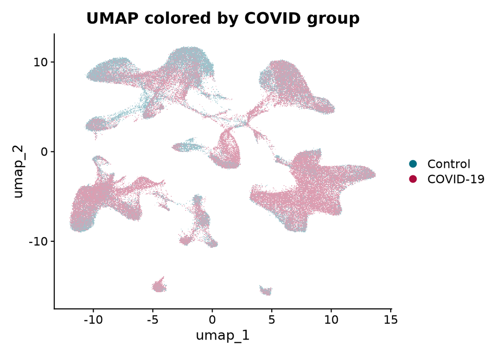

```r
# ——— UMAP colored by COVID group ———
DimPlot(
  object    = lung_seurat,       # purpose: the Seurat object that already contains UMAP embeddings
  reduction = "umap",            # purpose: tell DimPlot to use the precomputed UMAP coordinates
  group.by  = "group",           # purpose: color cells by 'group' (Control vs COVID-19)
  shuffle   = TRUE,              # purpose: randomize plotting order to reduce overplotting bias
  pt.size   = 0.4,
  cols      = c('#006E82', '#AA0A3C')
) +
  ggtitle("UMAP colored by COVID group")  # purpose: add a clear title in the knitted report
```

```
## Rasterizing points since number of points exceeds 100,000.
## To disable this behavior set `raster=FALSE`
```

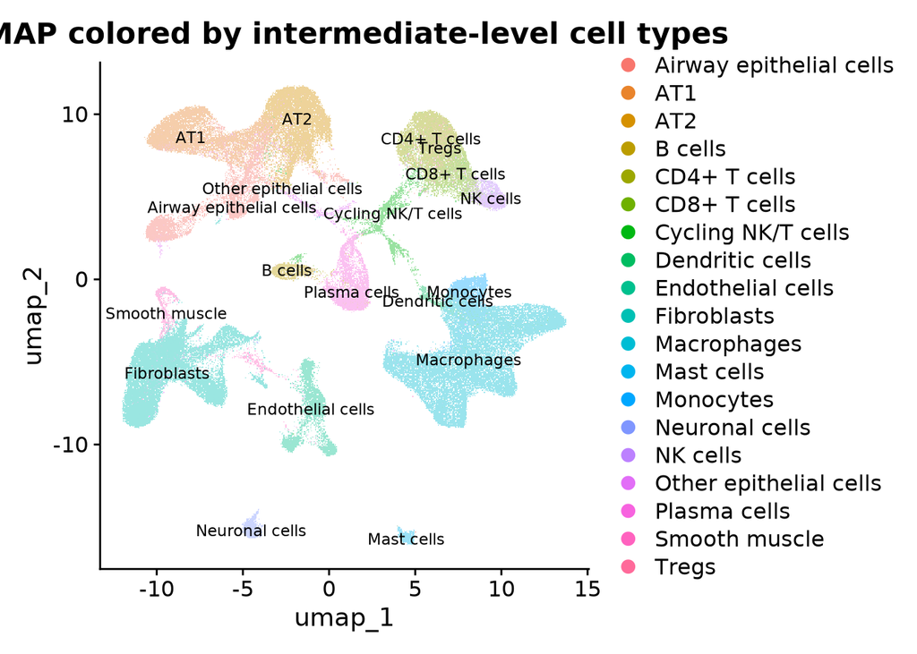

```r
# ——— UMAP colored by intermediate-level cell types ———
DimPlot(
  object    = lung_seurat,
  reduction = "umap",
  group.by  = "cell_type_intermediate",
  shuffle   = TRUE,
  pt.size   = 0.4,
  label     = TRUE,
  label.size= 3
) +
  ggtitle("UMAP colored by intermediate-level cell types")  # purpose: title for the second plot
```

After finishing this task, let’s remove this object from memory by executing the code chuck below.

```r
rm(lung_seurat)
gc()
```

```
##             used   (Mb) gc trigger    (Mb)   max used   (Mb)
## Ncells   3982491  212.7    7535598   402.5    7535598  402.5
## Vcells 949405989 7243.4 1622002793 12374.9 1015203439 7745.4
```

# Analysis of the alveolar epithelial cells

Next, let’s focus on the alveolar epithelial cells (AT1 and AT2 cells) in the data. Let’s first load the alveolar epithelial cells data.

```r
alv_epi_cells.seurat <- readRDS("/nfs/roberts/project/beng469f/shared/HW1/lung_avl_epi.RDS")
```

In the paper, the authors found that COVID-19 AT2 cells displayed decreased expression of ETV5 (Fig. 3d), a transcription factor that is required for maintaining AT2 cell identity. Decreased ETV5 expression is associated with differentiation towards AT1 cells, indicating that AT2 cells had initiated a regeneration program. Also, they found that CAV1, a marker of late AT1 maturation24, was expressed at lower levels in AT1 cells from COVID-19 lungs (Fig. 3e).

**TASK 2**: Please write codes in the following code chunk below to generate two separate violin plots: (1) comparing the expression levels of ETV5 between Control and COVID-19 groups in AT2 cells. (2) comparing the expression levels of CAV1 between Control and COVID-19 groups in AT1 cells.

(Hint 1: You can use the `subset()` function to subset the Seurat objects. AT1 and AT2 cells can be selected via logical expression `cell_type_fine == "AT1"` and `cell_type_fine == "AT2"`).

(Hint 2: Check the parameters of VlnPlot to see how to compare between Control and COVID-19 group (metadata name is `"group"`)). You need to set the default assay to RNA.

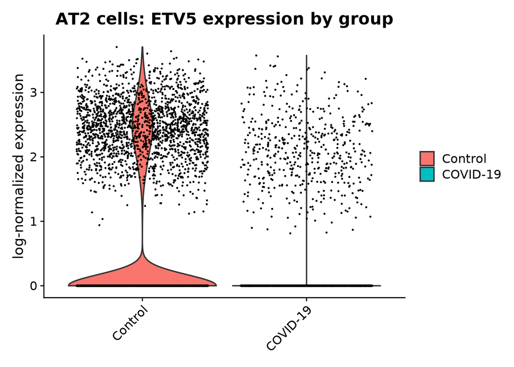

```r
# ---- TASK 2: Violin plots for ETV5 (AT2) and CAV1 (AT1) by COVID group ----
# Purpose: compare gene expression between Control and COVID-19 within specific alveolar epithelial subsets.

# Use RNA assay so plots reflect log-normalized RNA expression values
DefaultAssay(alv_epi_cells.seurat) <- "RNA"

# ----- AT2 subset & ETV5 violin -----
# Subset object to AT2 cells based on fine-grained cell-type label
alv_AT2 <- subset(alv_epi_cells.seurat, subset = cell_type_fine == "AT2")
# Order groups for consistent x-axis (Control -> COVID-19)
alv_AT2$group <- factor(alv_AT2$group, levels = c("Control","COVID-19"))

# Build the violin plot comparing ETV5 between groups in AT2 cells
p_at2_etv5 <- VlnPlot(
  object   = alv_AT2,          # AT2-only cells
  features = "ETV5",           # gene to visualize
  group.by = "group",          # split violins by COVID group
  pt.size  = 0.1               # tiny dots to show single-cell dispersion
) +
  labs(title = "AT2 cells: ETV5 expression by group",
       x = NULL, y = "log-normalized expression")
# ----- AT1 subset & CAV1 violin -----
# Subset object to AT1 cells
alv_AT1 <- subset(alv_epi_cells.seurat, subset = cell_type_fine == "AT1")
# Order groups for consistent x-axis
alv_AT1$group <- factor(alv_AT1$group, levels = c("Control","COVID-19"))

# Build the violin plot comparing CAV1 between groups in AT1 cells
p_at1_cav1 <- VlnPlot(
  object   = alv_AT1,
  features = "CAV1",
  group.by = "group",
  pt.size  = 0.1
) +
  labs(title = "AT1 cells: CAV1 expression by group",
       x = NULL, y = "log-normalized expression")

# ----- Render the plots in the notebook -----
p_at2_etv5
```

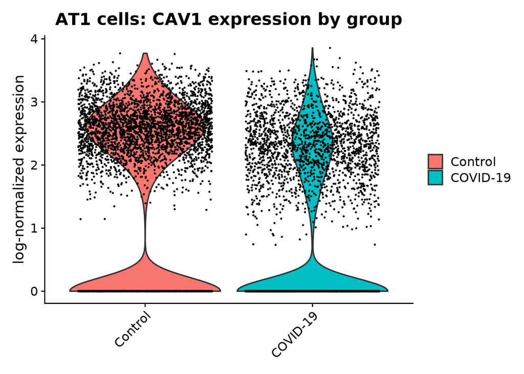

```r
p_at1_cav1
```

```r
# ----- (Optional) Save high-resolution copies for submission -----
ggsave("fig_task2_AT2_ETV5_violin.png", p_at2_etv5, width = 6, height = 5, dpi = 300)
ggsave("fig_task2_AT1_CAV1_violin.png", p_at1_cav1, width = 6, height = 5, dpi = 300)
```

Among these alveolar epithelial cells, a group of damage-associated transient progenitors (DATPs) cells was identified in the paper, as shown below in the UMAP visualization.

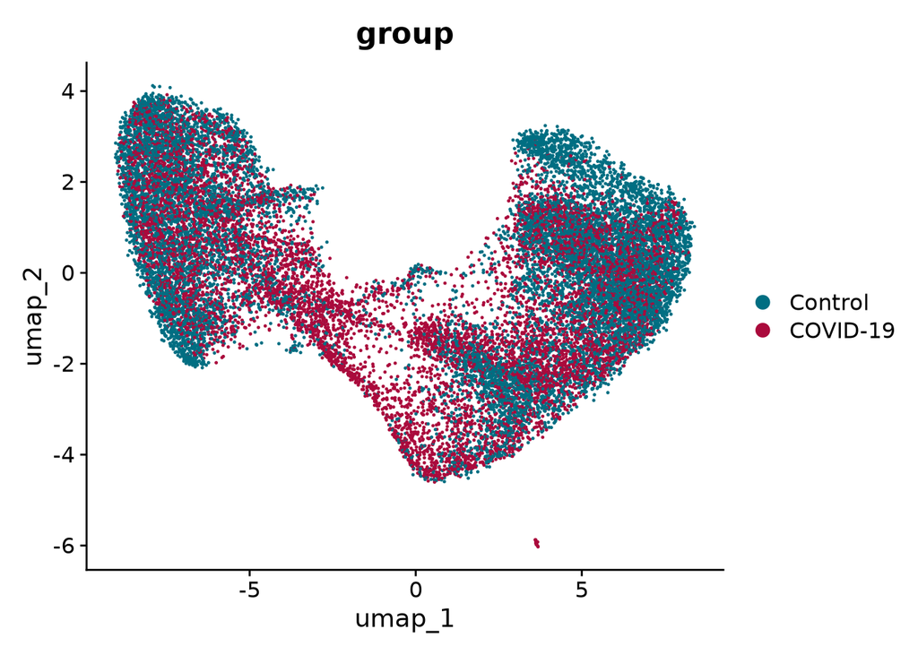

```r
DimPlot(alv_epi_cells.seurat,reduction = "umap",group.by = "group",shuffle = T,cols= c('#006E82', '#AA0A3C'))
```

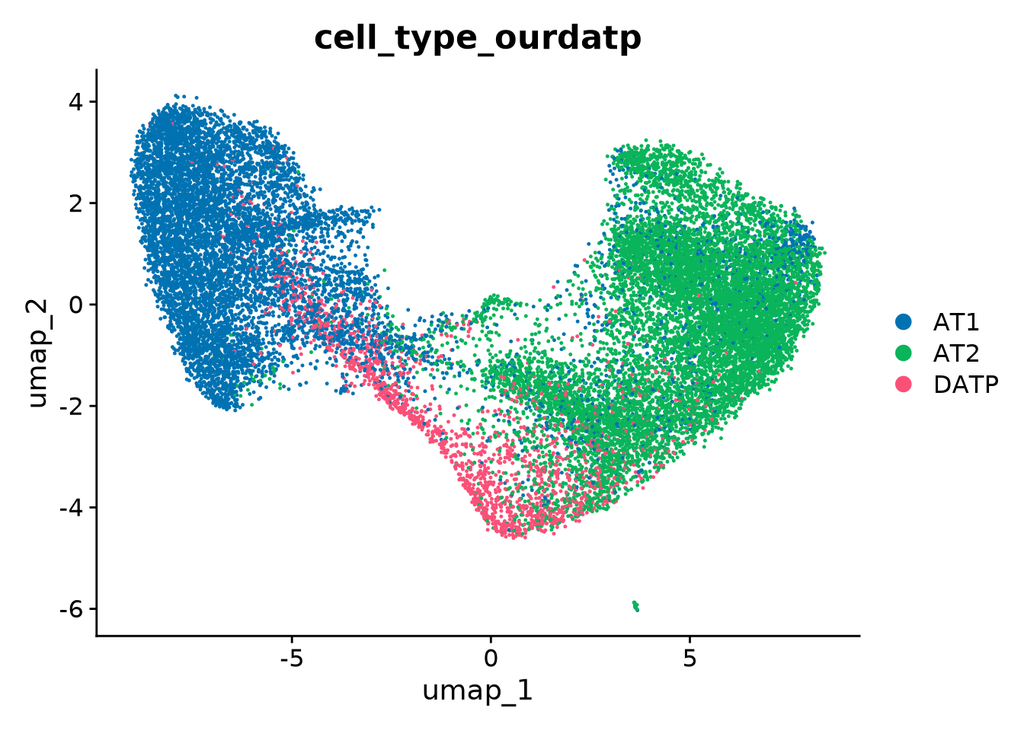

```r
DimPlot(alv_epi_cells.seurat,reduction = "umap",group.by = "cell_type_ourdatp",shuffle = T, cols = c('#0072B2', '#0AB45A', '#FA5078'))
```

To help identify these DATPs, the authors developed a DATP signature from different DATP marker genes (see Methods section).

**TASK 3**: Plot the signature scores on top of the cell UMAP embeddings using `FeaturePlot()` function, and see which cell group has high scores.

Hint: The feature name for the signature scores is `"our_DATP_sig1"` in the meta data column.

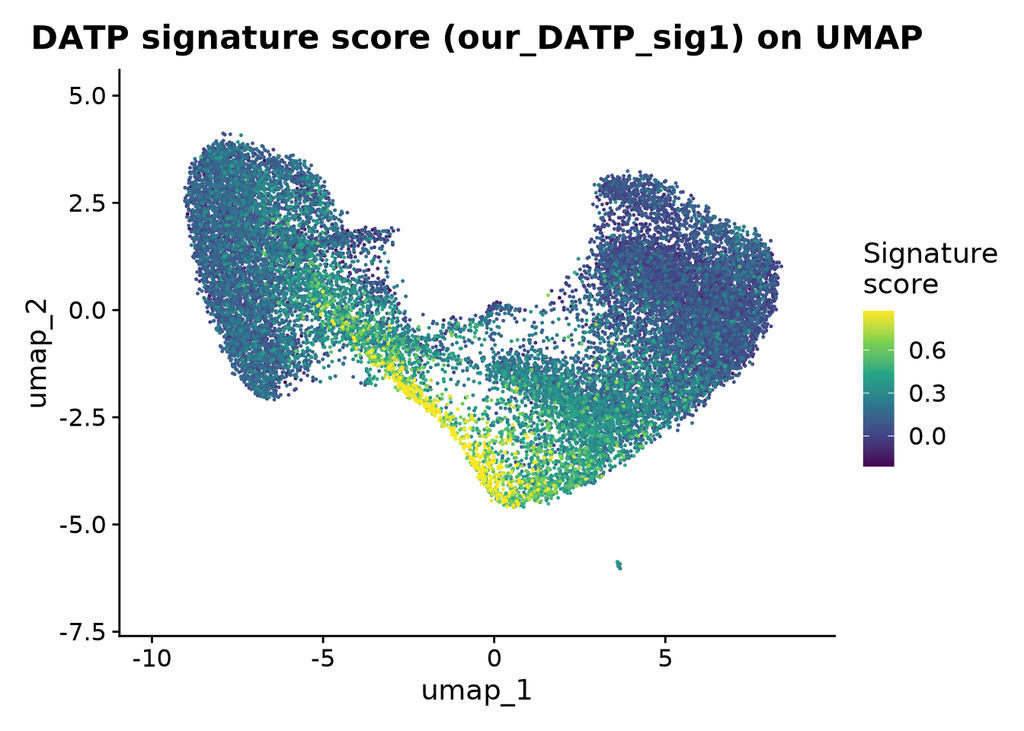

```r
# ---- TASK 3: Plot DATP signature (our_DATP_sig1) on UMAP with FeaturePlot ----
# Goal: overlay the DATP signature scores on the UMAP of alveolar epithelial cells
# so we can visually identify which cell populations have high DATP scores.

# 1) Sanity check: make sure the signature column exists in metadata.
stopifnot("our_DATP_sig1" %in% colnames(alv_epi_cells.seurat@meta.data))

# 2) Ensure the signature is numeric (some pipelines store it as character).
alv_epi_cells.seurat$our_DATP_sig1 <- as.numeric(alv_epi_cells.seurat$our_DATP_sig1)

# 3) Use RNA assay for consistency with previous plots (not strictly required for FeaturePlot on metadata).
DefaultAssay(alv_epi_cells.seurat) <- "RNA"

# 4) Compute a robust color range (1st–99th percentile) to improve contrast on the map.
q <- quantile(alv_epi_cells.seurat$our_DATP_sig1, probs = c(0.01, 0.99), na.rm = TRUE)

# 5) Draw the UMAP with the signature scores.
#    - reduction="umap": use the precomputed UMAP coordinates
#    - order=TRUE: plot higher values last so they are not overplotted
#    - min/max.cutoff: clip extreme values to stabilize color scaling
p_datp <- FeaturePlot(
  object    = alv_epi_cells.seurat,
  features  = "our_DATP_sig1",
  reduction = "umap",
  order     = TRUE,
  min.cutoff = q[1],
  max.cutoff = q[2]
) +
  scale_color_viridis_c() +
  labs(
    title = "DATP signature score (our_DATP_sig1) on UMAP",
    color = "Signature\nscore"
  )
# 6) Print the plot to the report.
p_datp
```

```r
# (Optional diagnostics you can uncomment if needed)
# VlnPlot(alv_epi_cells.seurat, features = "our_DATP_sig1", group.by = "cell_type_ourdatp", pt.size = 0) +
#   labs(title = "DATP signature by DATP annotation")
# VlnPlot(alv_epi_cells.seurat, features = "our_DATP_sig1", group.by = "group", pt.size = 0.1) +
#   labs(title = "DATP signature by COVID group")
```

After finishing this task, let’s remove this object from memory by executing the code chuck below.

```r
rm(alv_epi_cells.seurat)
gc()
```

```
##             used   (Mb) gc trigger    (Mb)   max used    (Mb)
## Ncells   4042160  215.9    7535599   402.5    7535599   402.5
## Vcells 229647121 1752.1 1557186681 11880.4 1712693129 13066.9
```

# Detailed annotation of fibroblasts in this study

Let’s first load the fibroblast data.

```r
fibroblast.seurat <-  readRDS("/nfs/roberts/project/beng469f/beng469f_my393/assignment1/lung_fibro.RDS")
```

In this paper, the authors spent huge efforts annotating the fibroblast populations to fine granularity. Below is a list of representive markers used for the fibroblast subtype identification (see Supplementary Table 4 for full reference) .

```r
fibroblast_marker_genes_selected <- c("MACF1","ABCA10","COL1A1","NCAM2","PDGFRB","MYH11","VWF","PKHD1L1","ITGBL1")
```

**TASK 4**: Complete the DotPlot function below to visualize the expression levels of these markers among the fine granular cell types.

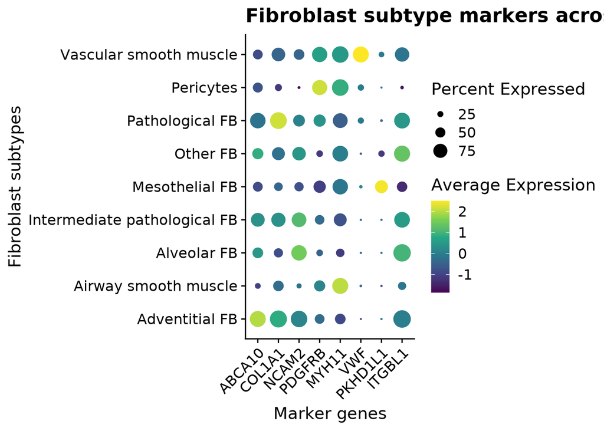

```r
# ---- TASK 4: DotPlot of fibroblast subtype markers across fine-grained cell types ----
DefaultAssay(fibroblast.seurat) <- "RNA"

DotPlot(
  fibroblast.seurat,
  features = fibroblast_marker_genes_selected,
  group.by = "cell_type_fine"
) +
  scale_color_viridis_c() +
  RotatedAxis() +
  labs(
    title = "Fibroblast subtype markers across fine-grained cell types",
    x = "Marker genes",
    y = "Fibroblast subtypes",
    color = "Avg. expression",
    size = "Pct. expressing"
  )
```

After finishing this task, let’s remove this object from memory by executing the code chuck below.

```r
rm(fibroblast.seurat)
gc()
```

```
##             used   (Mb) gc trigger   (Mb)   max used    (Mb)
## Ncells   4109087  219.5    7535599  402.5    7535599   402.5
## Vcells 415495047 3170.0 1245749345 9504.4 1712693129 13066.9
```

# Differential analysis of the alveolar macrophages between COVID and Control groups

One important finding in the paper is that myeloid cells from individuals with COVID-19 were highly and aberrantly activated. here let’s focus on the differential gene expression analysis of the alveolar macrophages between COVID and Control groups.

Similarly, let’s first load the data corresponding to alveolar macrophages.

```r
alv_macro.seurat <- readRDS("/nfs/roberts/project/beng469f/beng469f_my393/assignment1/lung_alv_macro.RDS")
```

**TASK 5**: In the code chuck below: please (1) complete `FindAllMarkers()` function to identify the differentially expressed genes of the alveolar macrophages between COVID and Control groups, and (2) complete `DoHeatmap()` to visualize the expression levels of the top 10 DEGs of each group in a heatmap

Hint: The parameters to use for `FindAllMarkers()` are specified in the paper’s Methods section.

```r
# ---- TASK 5: DEGs in alveolar macrophages (COVID-19 vs Control) + heatmap ----
# Goal:
# (1) Identify differentially expressed genes (DEGs) between COVID-19 and Control groups
#     among alveolar macrophages using FindAllMarkers().
# (2) Plot a heatmap of the top 10 upregulated genes for each group.

# Assumptions:
# - Object 'alv_macro.seurat' is already loaded (per earlier chunk).
# - The COVID status is stored in metadata column 'group' with values like "Control", "COVID-19".
# - Expression values are in the RNA assay.

# 0) Ensure we read expression from RNA assay
DefaultAssay(alv_macro.seurat) <- "RNA"

# 1) Set identities to the COVID group so FindAllMarkers contrasts groups
Idents(alv_macro.seurat) <- factor(alv_macro.seurat$group, levels = c("Control","COVID-19"))
# purpose: identities ("Idents") define groups compared by FindAllMarkers; we order for consistency.

# 2) Run differential expression
# Typical parameters aligned with common scRNA-seq practice and methods in similar re-analyses:
# - only.pos = TRUE: report genes upregulated in each identity (here, each group)
# - test.use = "wilcox": Wilcoxon rank-sum test per gene
# - min.pct = 0.25: gene must be expressed in at least 25% of cells in either group
# - logfc.threshold = 0.25: minimum log2 fold change to be considered
# - return.thresh = 0.05: adjusted p-value (FDR) cutoff
lung_alv_marco.markers <- FindAllMarkers(
  object         = alv_macro.seurat,
  only.pos       = TRUE,
  test.use       = "wilcox",
  min.pct        = 0.25,
  logfc.threshold= 0.25,
  return.thresh  = 0.05
)
```

[output not shown]

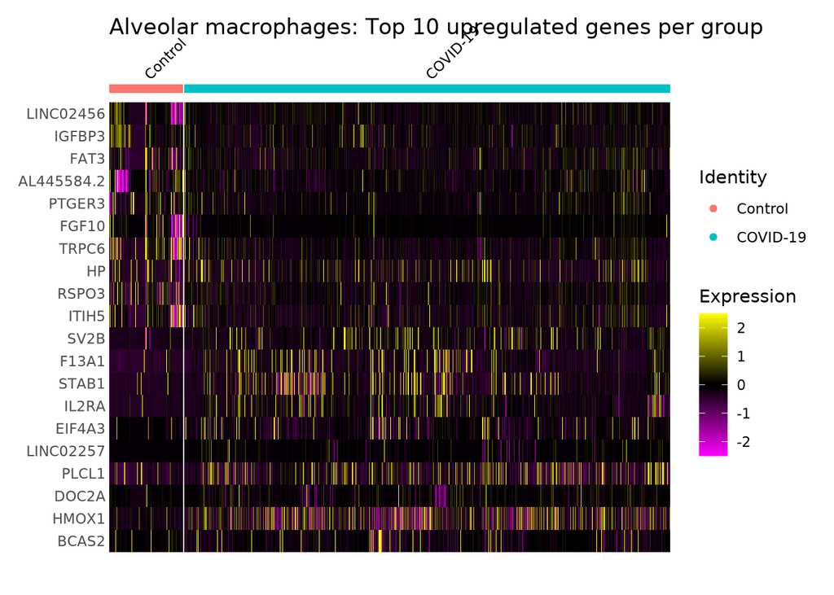

```r
# 3) Select top 10 DEGs (by avg_log2FC) from each group
# NOTE: dplyr::slice_max is the modern replacement for top_n.
lung_alv_marco.markers.top10 <- lung_alv_marco.markers %>%
  dplyr::group_by(cluster) %>%                       # 'cluster' here equals the identity (group)
  dplyr::slice_max(order_by = avg_log2FC, n = 10, with_ties = FALSE) %>%
  dplyr::arrange(cluster, dplyr::desc(avg_log2FC))

# 4) Prepare features and (optionally) scale them to improve heatmap contrast
features_top <- unique(lung_alv_marco.markers.top10$gene)
alv_macro.seurat <- ScaleData(alv_macro.seurat, features = features_top, verbose = FALSE)
# purpose: centers/scales only the selected features for nicer z-score heatmap without altering the object broadly

# 5) Draw the heatmap of top DEGs per group
# - group.by = "group": columns grouped by COVID vs Control
# - raster = TRUE: faster plotting for large cell numbers
# - size: controls label text size for row names
DoHeatmap(
  object   = alv_macro.seurat,
  features = features_top,
  group.by = "group",
  raster   = TRUE,
  size     = 3
) + ggtitle("Alveolar macrophages: Top 10 upregulated genes per group")
```

```r
# (Optional) Save a high-resolution copy
# ggsave("fig_task5_alv_mac_topDEG_heatmap.png", width = 10, height = 7, dpi = 300)

# (Optional) If you also want *downregulated* genes per group:
# rerun FindAllMarkers with only.pos = FALSE, then split by sign(avg_log2FC) within each cluster.
```

After completing the code chucks, please save this notebook and click `Knit to HTML` option under the `Knit` icon at the top to generate a corresponding html file.